# IE 360 Homework 4 & 5

İlayda Tezcan Tolga Erdoğan Tolgahan İskender

# Introduction

The purpose of this task is to come up with various forecasting techniques for our term project. Initially, seasonality will be analyzed for each product according to seasonality series will be decomposed. Unfortunately, due to lack of data only daily decomposition can be applied. The reason behind such problem is Trendyol does not share data before May 2020, which causes weekly and monthly decomposition not to be made. Based on decomposition for each product, proper ARIMA models will be build. Then, possible regressor analysis will made for each product according to relations with sold count. ARIMAX models will build with specified regressors to reach better forecast values.

Required libraries and data manipulations

```r
library(caTools)
library(xts)
library(zoo)
library(forecast)
library(urca)
library(ggplot2)


data[, is.discount_days:= 0]
rawdata <- read.csv("C:/Users/tolga/Documents/GitHub/spring21-Tolgahaniskender-1/files/HW4-5/ProjectRawData.csv", header=TRUE, sep = ";")
rawdata$event_date <- as.Date(rawdata$event_date , format = "%d.%m.%Y")
alldata<-rbind(rawdata,data)
alldata<-as.data.table(alldata)
alldata$is.discount_days[alldata$event_date=="2021-03-08"] <- 1
alldata$is.discount_days[alldata$event_date=="2021-03-09"] <- 1
alldata$is.discount_days[alldata$event_date=="2021-03-10"] <- 1
alldata$is.discount_days[alldata$event_date=="2021-03-11"] <- 1
alldata$is.discount_days[alldata$event_date=="2021-03-12"] <- 1

# Some of the other discount days are set to 1 in ProjectRawData.csv

n<-400
dates<- seq(as.Date("2020-05-25"), length = n, by = "days")
#validation_dates<-seq(as.Date("2021-03-01"), length = n-280, by = "days")
```

# Xiaomi Bluetooth Earphone

## Decomposition

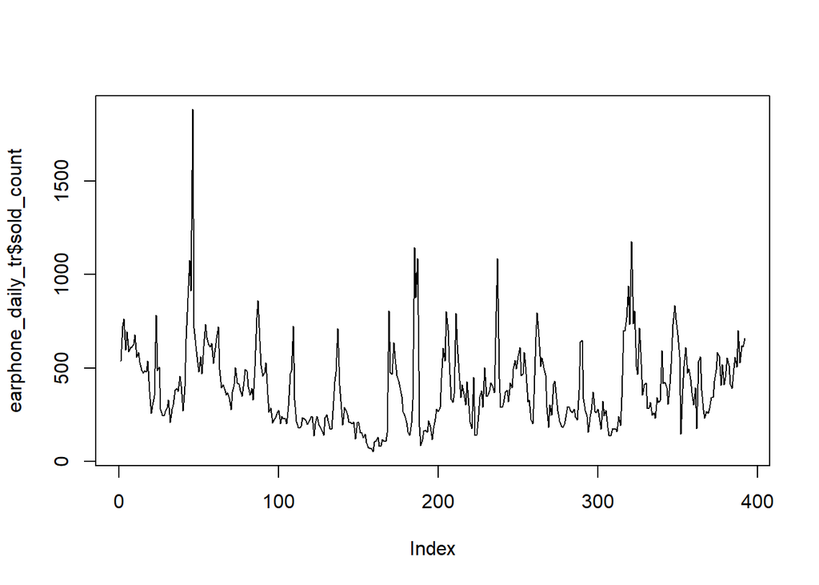

```r
earphone<-subset(alldata, alldata$product_content_id==6676673)
earphone_daily_tr<-earphone[earphone$event_date<"2021-06-21"]
earphone_daily_te<-earphone[earphone$event_date>="2021-06-21"]
plot(earphone_daily_tr$sold_count, type ='l')
```

Plot above shows sold counts of Xiaomi Bluetooth Earphone, which has no visible trend over time and variance seems constant, although there are outlier points.

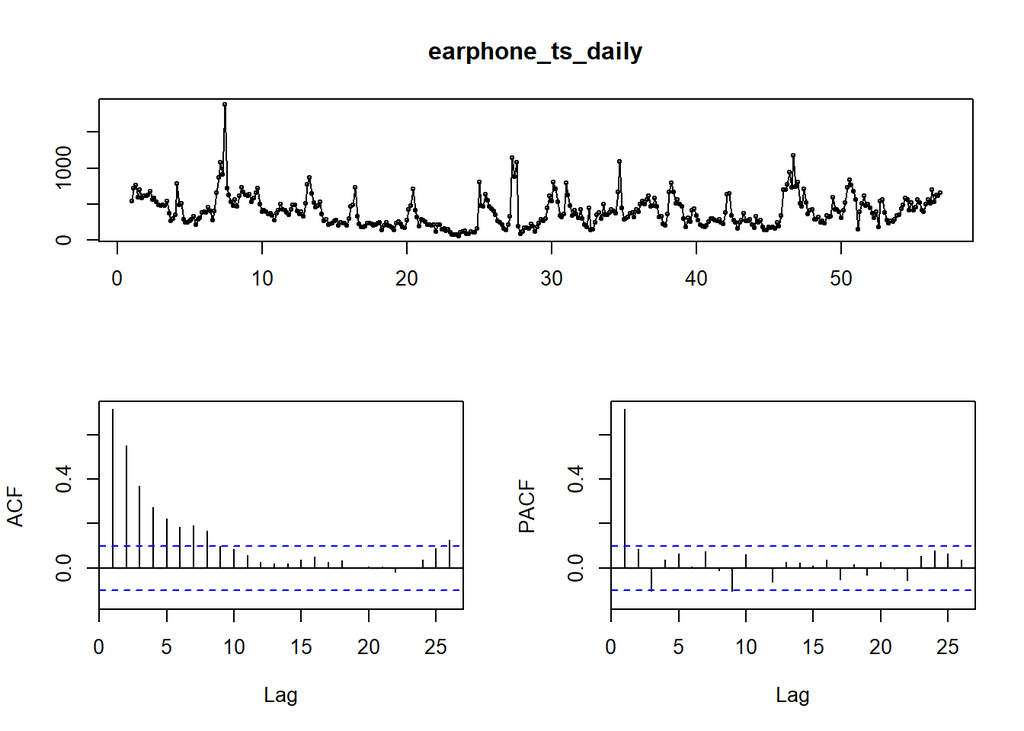

```r
earphone_ts_daily<-ts(earphone_daily_tr$sold_count, freq=7)
tsdisplay(earphone_ts_daily)
```

Necessary data manipulations are made in order to obtain daily data. ACF plot shows decreasing significant correlation until lag 8 and PACF shows only significant correlation at lag 1. It will be examined further after decomposition.

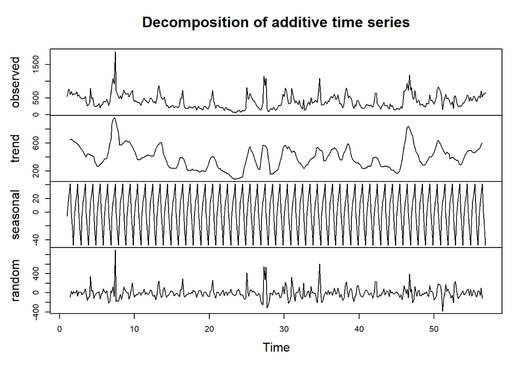

```r
earphone_daily_additive<-decompose(earphone_ts_daily, type ="additive")
earphone_daily_multiplicative<-decompose(earphone_ts_daily, type ="multiplicative")
plot(earphone_daily_additive)
```

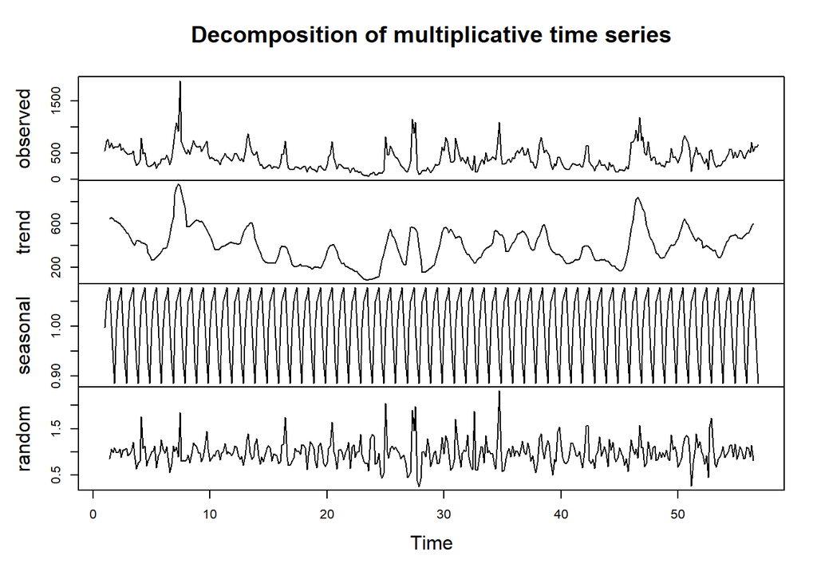

```r
plot(earphone_daily_multiplicative)
```

For additive decomposition random part has less variance compared to multiplicative approach. Also, multiplicative decomposition random part’s variance changes over time. For both model has zero mean for random part.

In order to understand which model is better, the method to be used in the continuation of the study can be decided by applying specific tests that can measure stationarity for random part.

```r
test11=ur.kpss(earphone_daily_additive$random, use.lag="7")
summary(test11)
```

```
##
## #######################
## # KPSS Unit Root Test #
## #######################
##
## Test is of type: mu with 7 lags.
##
## Value of test-statistic is: 0.0112
##
## Critical value for a significance level of:
##                 10pct  5pct 2.5pct  1pct
## critical values 0.347 0.463  0.574 0.739
```

```r
test12=ur.kpss(earphone_daily_multiplicative$random, use.lag="7")
summary(test12)
```

```
##
## #######################
## # KPSS Unit Root Test #
## #######################
##
## Test is of type: mu with 7 lags.
##
## Value of test-statistic is: 0.0336
##
## Critical value for a significance level of:
##                 10pct  5pct 2.5pct  1pct
## critical values 0.347 0.463  0.574 0.739
```

Additive decomposition gives more stationary random part compared to multiplicative according value of test statisctic and critical values. Hence, additive is chosen for further examinations.

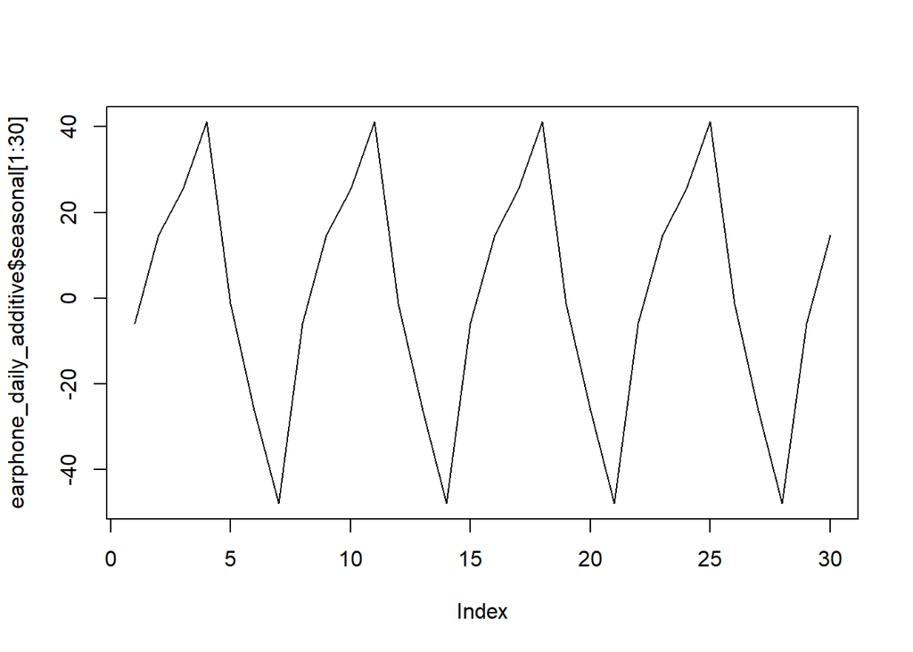

```r
plot(earphone_daily_additive$seasonal[1:30], type='l')
```

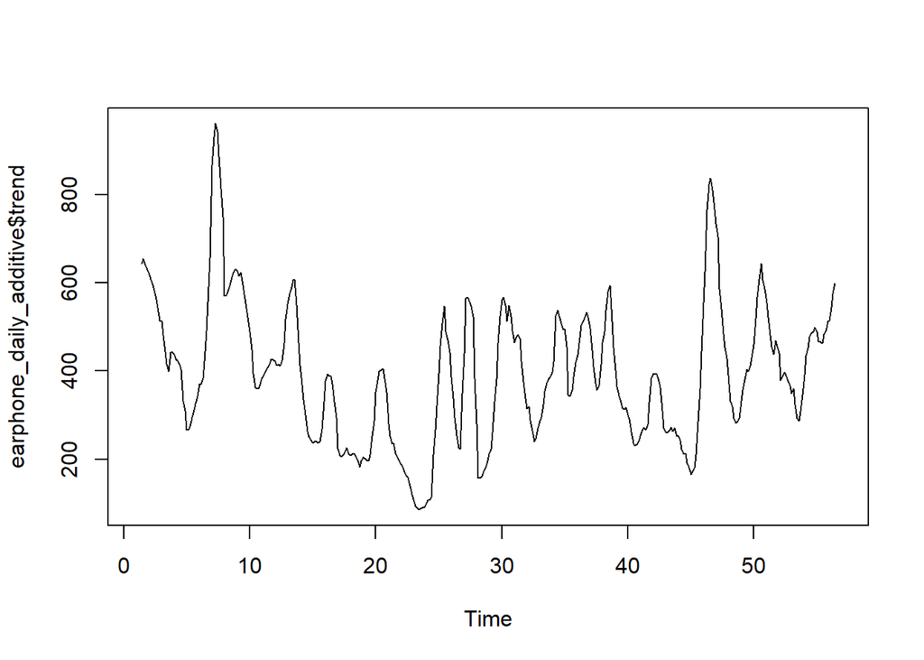

```r
plot(earphone_daily_additive$trend, type='l')
```

Plots above show closer looks for trend and seasonal components of additive decomposition .

Since there are not enough data points, decomposition cannot made different levels. Altough we cannot decompose, weekly and monthly plots can be seen below.

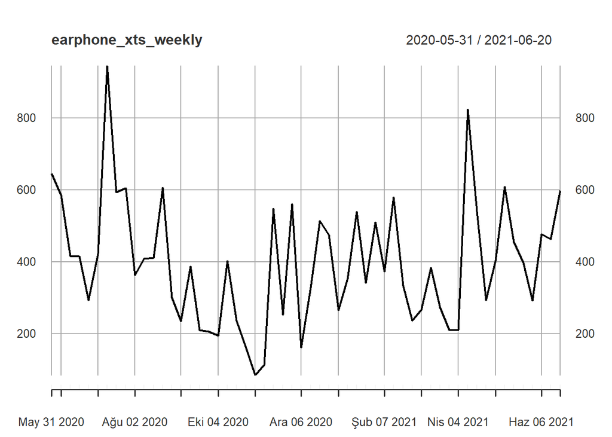

```r
earphone_xts<-xts(earphone_daily_tr$sold_count, order.by=as.Date(earphone_daily_tr$event_date,"%d.%m.%Y"))
weekly<-endpoints(earphone_xts,on="weeks")
earphone_xts_weekly<-period.apply(earphone_xts,INDEX=weekly,FUN=mean)
plot(earphone_xts_weekly)
```

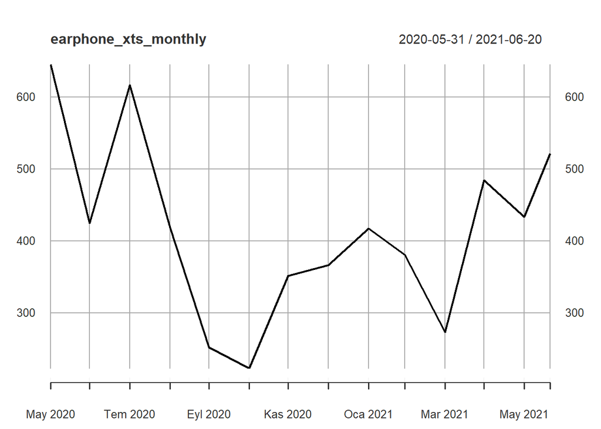

```r
monthly<-endpoints(earphone_xts,on="months")
earphone_xts_monthly<-period.apply(earphone_xts,INDEX=monthly,FUN=mean)
plot(earphone_xts_monthly)
```

Weekly and monthly plots does not show any significant pattern or trend. If we had more data points, maybe a more meaningful result could be reached from these graphs.

## ARIMA Model

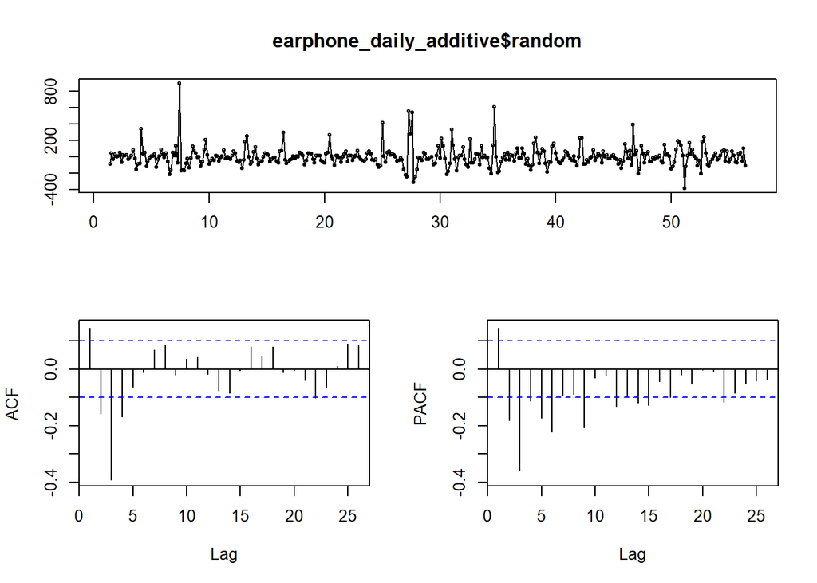

```r
tsdisplay(earphone_daily_additive$random, na.action = na.omit)
```

According to ACF plot, there is significant negative correlation at lag 3. Hence, moving average parameter should be 3. Also, it can be seen from PACF plot that correlation significantly decreased after lag 3 which means that AR parameter should be 3.

```r
earphone_model<-arima(earphone_daily_additive$random, order = c(3,0,3))
AIC(earphone_model)
```

```
## [1] 4641.866
```

```r
earphone_model2<-arima(earphone_daily_additive$random, order = c(3,0,2))
AIC(earphone_model2)
```

```
## [1] 4639.877
```

```r
earphone_model3<-arima(earphone_daily_additive$random, order = c(2,0,2))
AIC(earphone_model3)
```

```
## [1] 4643.746
```

When adjacent parameters also checked, model 2 which has (3,0,2) parameters is better in terms of AIC values, therefore it is chosen.

Fitting the model

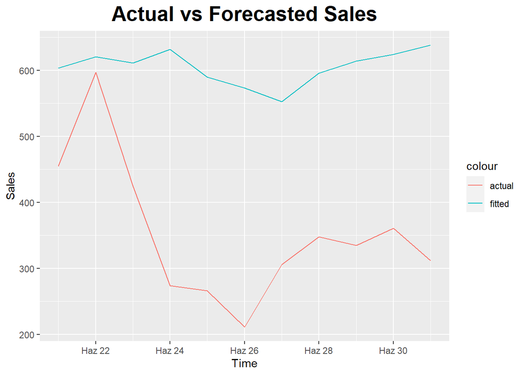

```r
model_forecast_error <- predict(earphone_model2, n.ahead = 11)$pred
last_trend_value <-tail(earphone_daily_additive$trend[!is.na(earphone_daily_additive$trend)],1)
seasonality=earphone_daily_additive$seasonal[295:305]
earphone_arima_forecast=model_forecast_error+seasonality+last_trend_value

earphone_daily_te$forecast<-paste(earphone_arima_forecast)
earphone_daily_te$forecast<-as.numeric(earphone_daily_te$forecast)


ggplot(earphone_daily_te ,aes(x=event_date)) +
        geom_line(aes(y=sold_count,color='actual')) +
        geom_line(aes(y=forecast,color='fitted')) + labs(title = "Actual vs Forecasted Sales",
       x = "Time",
       y = "Sales"
       )+
  theme(plot.title = element_text(color = "black", size = 20, face = "bold", hjust = 0.5),
        plot.subtitle = element_text(size = 10, face = "bold", hjust = 0.5),
        plot.caption = element_text(face = "italic", hjust = 0))
```

```r
error_test(earphone_daily_te$sold_count,earphone_daily_te$forecast)
```

```
##    n     mean       sd       bias      mape      mad     wmape        MPE
## 1 11 353.6364 106.4878 -0.7109682 0.8337796 251.4242 0.7109682 -0.8337796
```

## Regressor Search

```r
earphone_lm1<-lm(sold_count~visit_count+is.discount_days, data=earphone_daily_tr)
summary(earphone_lm1)
```

```
##
## Call:
## lm(formula = sold_count ~ visit_count + is.discount_days, data = earphone_daily_tr)
##
## Residuals:
##     Min      1Q  Median      3Q     Max
## -374.74 -148.02  -34.11  115.73 1524.98
##
## Coefficients:
##                   Estimate Std. Error t value Pr(>|t|)
## (Intercept)      3.580e+02  1.267e+01  28.252  < 2e-16 ***
## visit_count      4.675e-03  9.428e-04   4.958 1.06e-06 ***
## is.discount_days 1.727e+02  5.445e+01   3.172  0.00163 **
## ---
## Signif. codes:  0 '***' 0.001 '**' 0.01 '*' 0.05 '.' 0.1 ' ' 1
##
## Residual standard error: 206.8 on 389 degrees of freedom
## Multiple R-squared:  0.0815, Adjusted R-squared:  0.07678
## F-statistic: 17.26 on 2 and 389 DF,  p-value: 6.585e-08
```

```r
earphone_lm2<-lm(sold_count~category_sold+price, data=earphone_daily_tr)
summary(earphone_lm2)
```

```
##
## Call:
## lm(formula = sold_count ~ category_sold + price, data = earphone_daily_tr)
##
## Residuals:
##     Min      1Q  Median      3Q     Max
## -375.08 -108.80  -24.71   84.28 1312.29
##
## Coefficients:
##                 Estimate Std. Error t value Pr(>|t|)
## (Intercept)    1.398e+03  1.146e+02  12.201   <2e-16 ***
## category_sold  1.943e-02  9.117e-03   2.132   0.0337 *
## price         -7.522e+00  8.016e-01  -9.385   <2e-16 ***
## ---
## Signif. codes:  0 '***' 0.001 '**' 0.01 '*' 0.05 '.' 0.1 ' ' 1
##
## Residual standard error: 183 on 389 degrees of freedom
## Multiple R-squared:  0.281,  Adjusted R-squared:  0.2773
## F-statistic:    76 on 2 and 389 DF,  p-value: < 2.2e-16
```

```r
earphone_lm3<-lm(sold_count~price+favored_count+category_sold, data=earphone_daily_tr)
summary(earphone_lm3)
```

```
##
## Call:
## lm(formula = sold_count ~ price + favored_count + category_sold,
##     data = earphone_daily_tr)
##
## Residuals:
##     Min      1Q  Median      3Q     Max
## -374.26 -105.48  -26.86   70.39 1335.15
##
## Coefficients:
##                 Estimate Std. Error t value Pr(>|t|)
## (Intercept)    1.347e+03  1.175e+02  11.465   <2e-16 ***
## price         -7.230e+00  8.140e-01  -8.882   <2e-16 ***
## favored_count  2.029e-02  1.082e-02   1.874   0.0616 .
## category_sold  1.713e-02  9.171e-03   1.868   0.0625 .
## ---
## Signif. codes:  0 '***' 0.001 '**' 0.01 '*' 0.05 '.' 0.1 ' ' 1
##
## Residual standard error: 182.4 on 388 degrees of freedom
## Multiple R-squared:  0.2874, Adjusted R-squared:  0.2819
## F-statistic: 52.16 on 3 and 388 DF,  p-value: < 2.2e-16
```

```r
earphone_lm4<-lm(sold_count~favored_count+basket_count+visit_count, data=earphone_daily_tr)
summary(earphone_lm4)
```

```
##
## Call:
## lm(formula = sold_count ~ favored_count + basket_count + visit_count,
##     data = earphone_daily_tr)
##
## Residuals:
##     Min      1Q  Median      3Q     Max
## -692.89  -41.70    2.91   57.37  348.83
##
## Coefficients:
##                 Estimate Std. Error t value Pr(>|t|)
## (Intercept)   15.7185477 12.4203458   1.266  0.20643
## favored_count -0.0229077  0.0083911  -2.730  0.00662 **
## basket_count   0.2587852  0.0078698  32.883  < 2e-16 ***
## visit_count   -0.0002814  0.0006716  -0.419  0.67549
## ---
## Signif. codes:  0 '***' 0.001 '**' 0.01 '*' 0.05 '.' 0.1 ' ' 1
##
## Residual standard error: 107.2 on 388 degrees of freedom
## Multiple R-squared:  0.754,  Adjusted R-squared:  0.7521
## F-statistic: 396.5 on 3 and 388 DF,  p-value: < 2.2e-16
```

```r
earphone_daily_te$forecastlm1<-predict(earphone_lm1,earphone_daily_te)
earphone_daily_te$forecastlm2<-predict(earphone_lm2,earphone_daily_te)
earphone_daily_te$forecastlm3<-predict(earphone_lm3,earphone_daily_te)
earphone_daily_te$forecastlm4<-predict(earphone_lm4,earphone_daily_te)

error_test(earphone_daily_te$sold_count,earphone_daily_te$forecastlm1)
```

```
##    n     mean       sd       bias      mape      mad     wmape        MPE
## 1 11 353.6364 106.4878 -0.2127934 0.3463527 103.3834 0.2923437 -0.2973753
```

```r
error_test(earphone_daily_te$sold_count,earphone_daily_te$forecastlm2)
```

```
##    n     mean       sd      bias     mape      mad    wmape       MPE
## 1 11 353.6364 106.4878 -0.644767 0.743205 228.0131 0.644767 -0.743205
```

```r
error_test(earphone_daily_te$sold_count,earphone_daily_te$forecastlm3)
```

```
##    n     mean       sd       bias      mape      mad     wmape        MPE
## 1 11 353.6364 106.4878 -0.6301594 0.7262419 222.8473 0.6301594 -0.7262419
```

```r
error_test(earphone_daily_te$sold_count,earphone_daily_te$forecastlm4)
```

```
##    n     mean       sd      bias      mape      mad     wmape       MPE
## 1 11 353.6364 106.4878 0.1521102 0.1459123 55.23074 0.1561795 0.1390922
```

4 different multiple linear regression model is built to understand which regressors are explaining model better. In terms of adjusted R square and WMAPE 4th model is explaining sales behavior better than others. Therefore, 4th model’s regressors will be chosen which are favored count, basket count and visit count.

## ARIMAX Model

```r
earphone_xreg1<-cbind(earphone_daily_tr$favored_count,
                  earphone_daily_tr$basket_count,
                  earphone_daily_tr$visit_count)
earphone_xreg2<-cbind(earphone_daily_te$favored_count,
                  earphone_daily_te$basket_count,
                  earphone_daily_te$visit_count)

earphone_arimax<-Arima(earphone_ts_daily,xreg=as.matrix(earphone_xreg1),order=c(3,0,2))
earphone_daily_te$forecastarimax<-forecast(earphone_arimax,xreg=as.matrix(earphone_xreg2))$mean
error_test(earphone_daily_te$sold_count,earphone_daily_te$forecastarimax)
```

```
##    n     mean       sd       bias      mape      mad     wmape        MPE
## 1 11 353.6364 106.4878 -0.1613391 0.2019397 57.68401 0.1631167 -0.2008867
```

WMAPE is 0.16 which is little higher than multiple linear regression model with same regressors. Plot below shows forecasted values with ARIMAX vs actual sales.

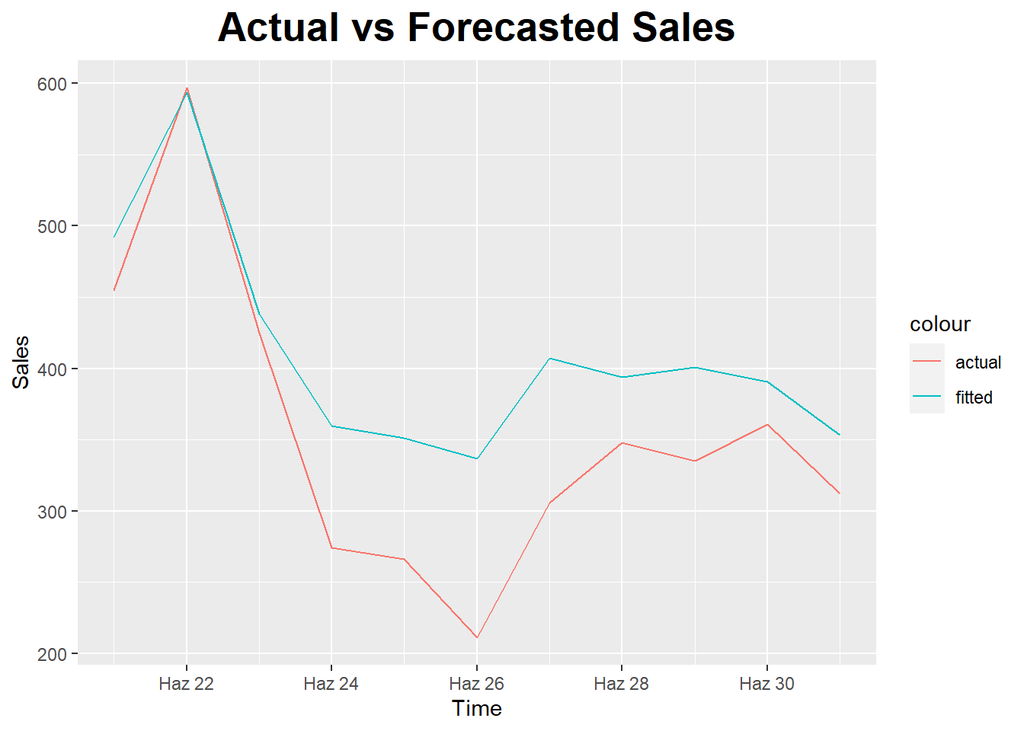

```r
ggplot(earphone_daily_te ,aes(x=event_date)) +
        geom_line(aes(y=sold_count,color='actual')) +
        geom_line(aes(y=forecastarimax,color='fitted')) + labs(title = "Actual vs Forecasted Sales",
       x = "Time",
       y = "Sales"
       )+
  theme(plot.title = element_text(color = "black", size = 20, face = "bold", hjust = 0.5),
        plot.subtitle = element_text(size = 10, face = "bold", hjust = 0.5),
        plot.caption = element_text(face = "italic", hjust = 0))
```

There is excessive difference forecasted values between ARIMA and ARIMAX models. As can be seen from plot above, regressors improved model incontestably.

# Fakir Vacuum Cleaner

## Decomposition

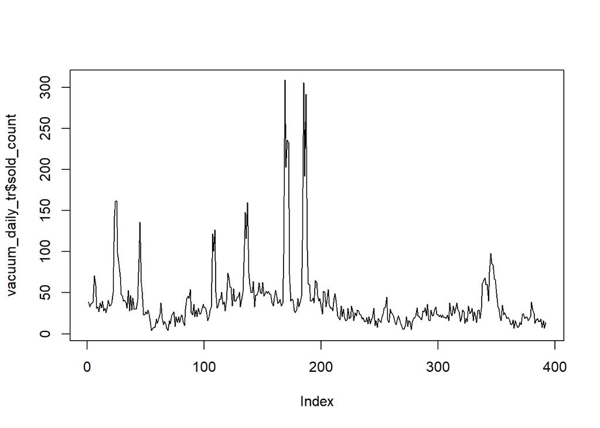

```r
vacuum<-subset(alldata, alldata$product_content_id==7061886)
vacuum_daily_tr<-vacuum[vacuum$event_date<"2021-06-21"]
vacuum_daily_te<-vacuum[vacuum$event_date>="2021-06-21"]
plot(vacuum_daily_tr$sold_count, type ='l')
```

Fakir vacuum cleaner daily sold count plot for given days can be seen above. Sales of item has significant visible outlier points.

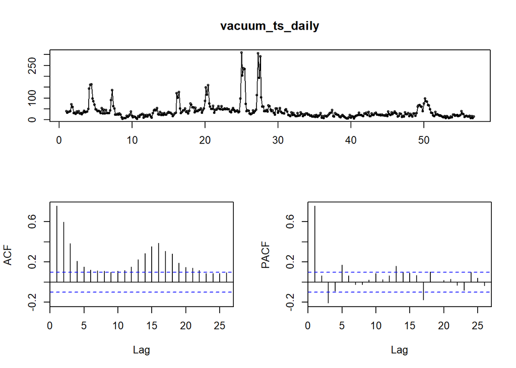

```r
vacuum_ts_daily<-ts(vacuum_daily_tr$sold_count, freq=7)
tsdisplay(vacuum_ts_daily)
```

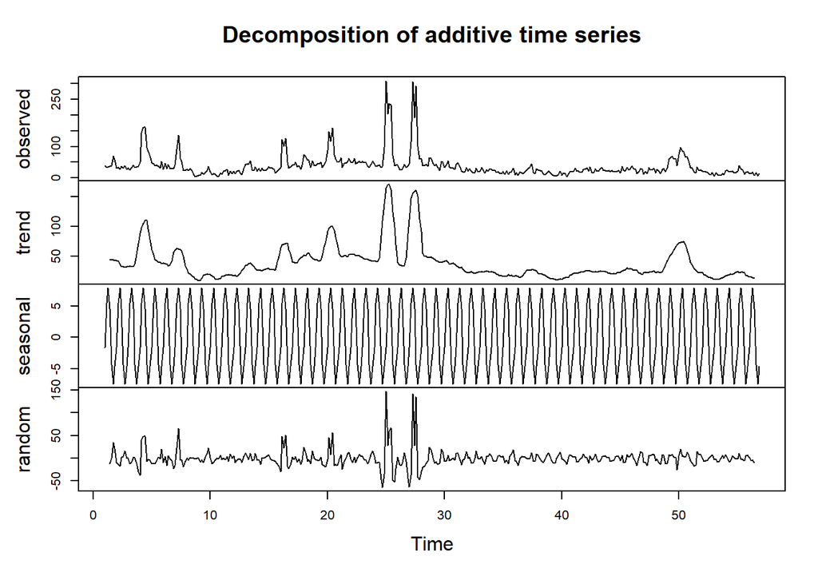

```r
vacuum_daily_additive<-decompose(vacuum_ts_daily, type ="additive")
vacuum_daily_multiplicative<-decompose(vacuum_ts_daily, type ="multiplicative")
plot(vacuum_daily_additive)
```

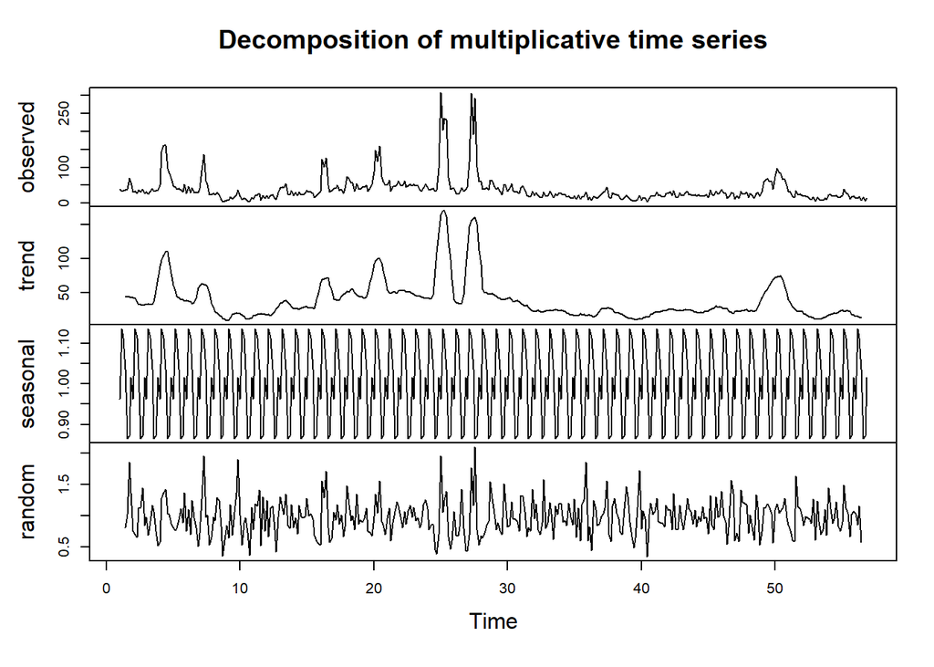

```r
plot(vacuum_daily_multiplicative)
```

Additive decomposition random part yield better result in terms of variance.

In order to understand which model is better, the method to be used in the continuation of the study can be decided by applying specific tests that can measure stationarity for random part.

```r
test13=ur.kpss(vacuum_daily_additive$random, use.lag="7")
summary(test13)
```

```
##
## #######################
## # KPSS Unit Root Test #
## #######################
##
## Test is of type: mu with 7 lags.
##
## Value of test-statistic is: 0.0111
##
## Critical value for a significance level of:
##                 10pct  5pct 2.5pct  1pct
## critical values 0.347 0.463  0.574 0.739
```

```r
test14=ur.kpss(vacuum_daily_multiplicative$random, use.lag="7")
summary(test14)
```

```
##
## #######################
## # KPSS Unit Root Test #
## #######################
##
## Test is of type: mu with 7 lags.
##
## Value of test-statistic is: 0.1153
##
## Critical value for a significance level of:
##                 10pct  5pct 2.5pct  1pct
## critical values 0.347 0.463  0.574 0.739
```

As expected from random part graphs, additive decomposition gave more stationary random part.

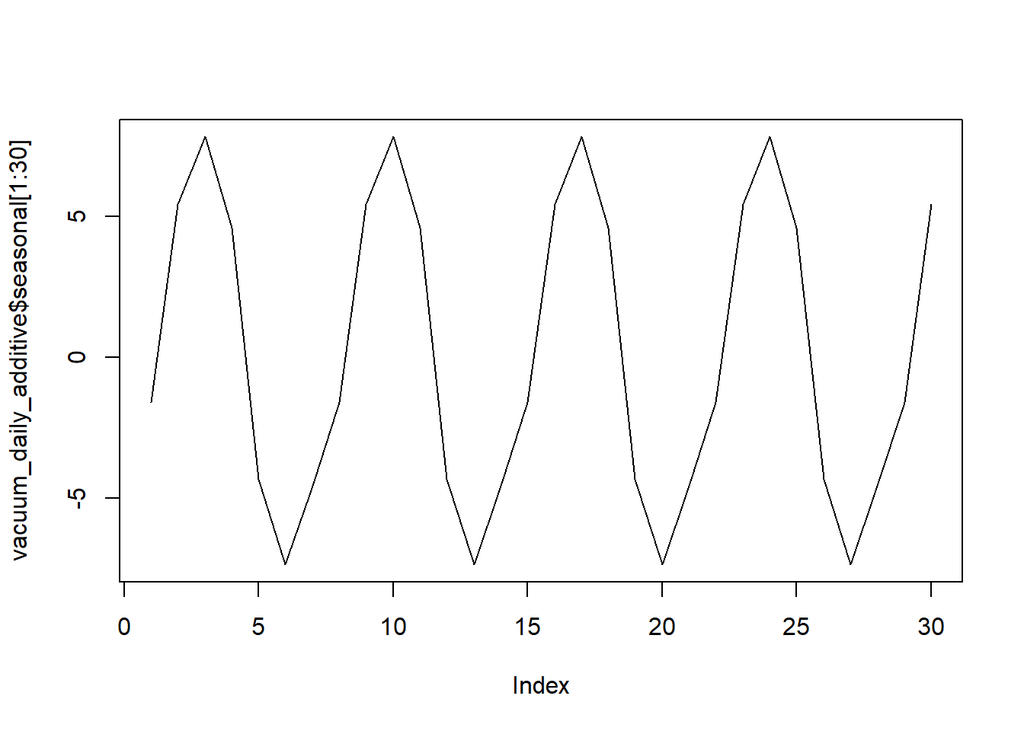

```r
plot(vacuum_daily_additive$seasonal[1:30], type='l')
```

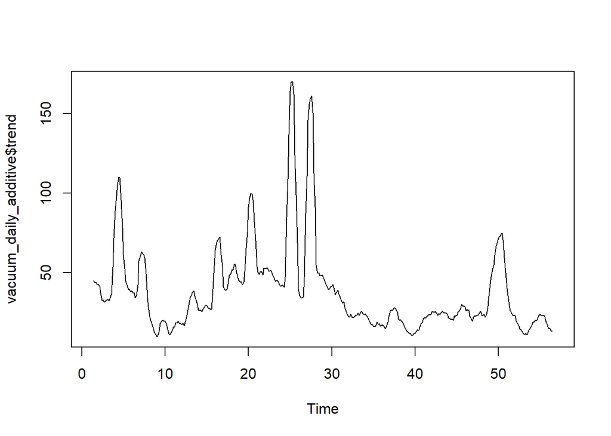

```r
plot(vacuum_daily_additive$trend, type='l')
```

Plots above show closer looks for trend and seasonal components of additive decomposition .

Since there are not enough data points, decomposition cannot made different levels. Altough we cannot decompose, weekly and monthly plots can be seen below.

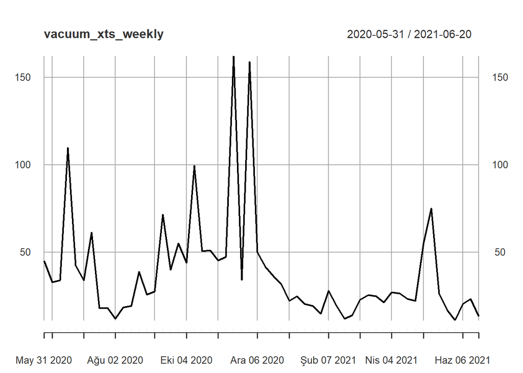

```r
vacuum_xts<-xts(vacuum_daily_tr$sold_count, order.by=as.Date(vacuum_daily_tr$event_date,"%d.%m.%Y"))
weekly<-endpoints(vacuum_xts,on="weeks")
vacuum_xts_weekly<-period.apply(vacuum_xts,INDEX=weekly,FUN=mean)
plot(vacuum_xts_weekly)
```

The peaks in November coincide with the trendyol discount days and black friday days that we determined in our project.

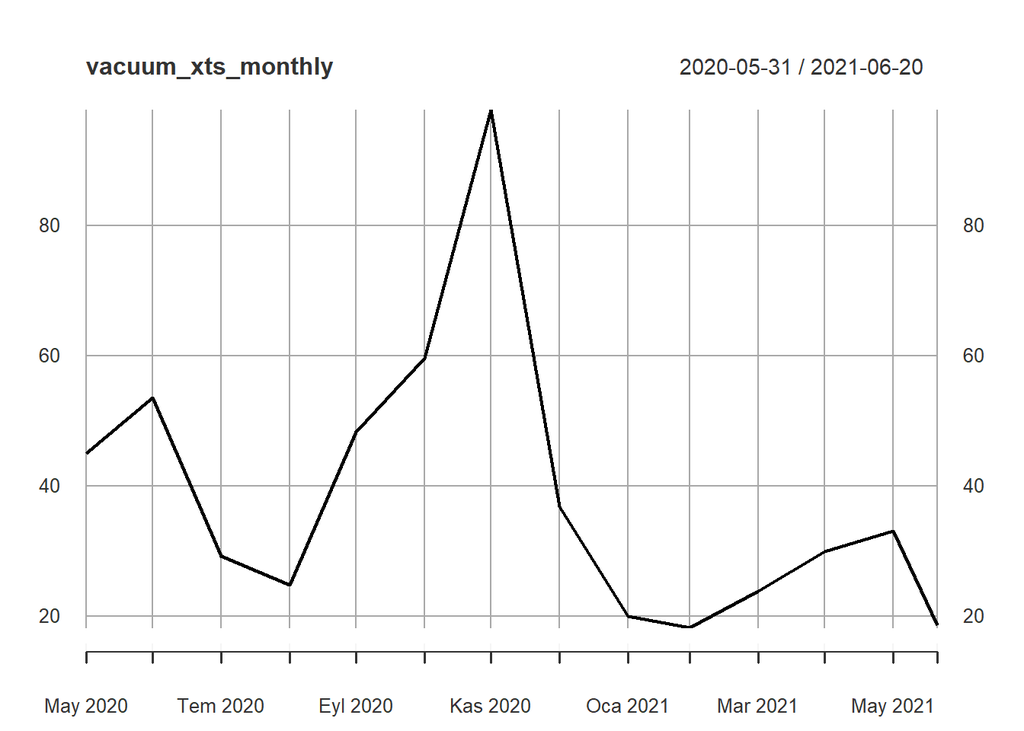

```r
monthly<-endpoints(vacuum_xts,on="months")
vacuum_xts_monthly<-period.apply(vacuum_xts,INDEX=monthly,FUN=mean)
plot(vacuum_xts_monthly)
```

From monthly sales data, november has highest sales which is expected due to price discounts and advertisements.

## ARIMA Model

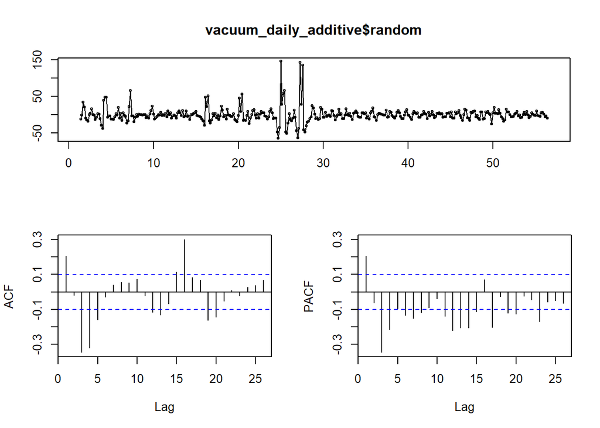

```r
tsdisplay(vacuum_daily_additive$random, na.action = na.omit)
```

According to ACF plot, there is significant negative correlation at lag 3. Hence, moving average parameter should be 3. Also, it can be seen from PACF plot that correlation significantly decreased after lag 1 which means that AR parameter should be 1.

```r
vacuum_model<-arima(vacuum_daily_additive$random, order = c(1,0,3))
AIC(vacuum_model)
```

```
## [1] 3268.003
```

```r
vacuum_model2<-arima(vacuum_daily_additive$random, order = c(1,0,2))
AIC(vacuum_model2)
```

```
## [1] 3375.757
```

```r
vacuum_model3<-arima(vacuum_daily_additive$random, order = c(2,0,2))
AIC(vacuum_model3)
```

```
## [1] 3354.103
```

When adjacent parameters also checked, still model 1 which has (1,0,3) parameters is better in terms of AIC values, therefore it is chosen.

Fitting the model

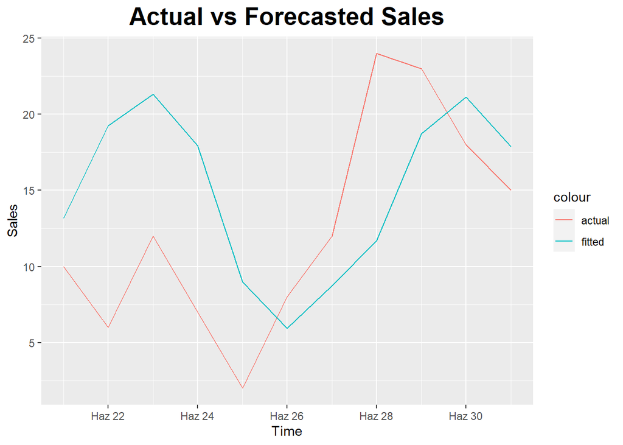

```r
model_forecast_error <- predict(vacuum_model, n.ahead = 11)$pred
last_trend_value <-tail(vacuum_daily_additive$trend[!is.na(vacuum_daily_additive$trend)],1)
seasonality=vacuum_daily_additive$seasonal[295:305]
vacuum_arima_forecast=model_forecast_error+seasonality+last_trend_value

vacuum_daily_te$forecast<-paste(vacuum_arima_forecast)
vacuum_daily_te$forecast<-as.numeric(vacuum_daily_te$forecast)


ggplot(vacuum_daily_te ,aes(x=event_date)) +
        geom_line(aes(y=sold_count,color='actual')) +
        geom_line(aes(y=forecast,color='fitted')) + labs(title = "Actual vs Forecasted Sales",
       x = "Time",
       y = "Sales"
       )+
  theme(plot.title = element_text(color = "black", size = 20, face = "bold", hjust = 0.5),
        plot.subtitle = element_text(size = 10, face = "bold", hjust = 0.5),
        plot.caption = element_text(face = "italic", hjust = 0))
```

```r
error_test(vacuum_daily_te$sold_count,vacuum_daily_te$forecast)
```

```
##    n     mean       sd       bias     mape      mad     wmape        MPE
## 1 11 12.45455 6.990903 -0.2023177 0.904415 6.506546 0.5224234 -0.6808567
```

## Regressor Search

```r
vacuum_lm1<-lm(sold_count~visit_count+is.discount_days, data=vacuum_daily_tr)
summary(vacuum_lm1)
```

```
##
## Call:
## lm(formula = sold_count ~ visit_count + is.discount_days, data = vacuum_daily_tr)
##
## Residuals:
##      Min       1Q   Median       3Q      Max
## -128.701  -15.605   -5.764    6.033  158.580
##
## Coefficients:
##                    Estimate Std. Error t value Pr(>|t|)
## (Intercept)       36.967454   1.918260  19.271  < 2e-16 ***
## visit_count       -0.003763   0.001448  -2.599  0.00969 **
## is.discount_days 113.452407   8.294838  13.677  < 2e-16 ***
## ---
## Signif. codes:  0 '***' 0.001 '**' 0.01 '*' 0.05 '.' 0.1 ' ' 1
##
## Residual standard error: 31.5 on 389 degrees of freedom
## Multiple R-squared:  0.333,  Adjusted R-squared:  0.3295
## F-statistic: 97.09 on 2 and 389 DF,  p-value: < 2.2e-16
```

```r
vacuum_lm2<-lm(sold_count~category_sold+price, data=vacuum_daily_tr)
summary(vacuum_lm2)
```

```
##
## Call:
## lm(formula = sold_count ~ category_sold + price, data = vacuum_daily_tr)
##
## Residuals:
##      Min       1Q   Median       3Q      Max
## -115.151  -15.039    2.828   10.488  186.436
##
## Coefficients:
##                 Estimate Std. Error t value Pr(>|t|)
## (Intercept)   207.969490  16.240448   12.81   <2e-16 ***
## category_sold   0.103703   0.007536   13.76   <2e-16 ***
## price          -0.725780   0.062501  -11.61   <2e-16 ***
## ---
## Signif. codes:  0 '***' 0.001 '**' 0.01 '*' 0.05 '.' 0.1 ' ' 1
##
## Residual standard error: 29.69 on 389 degrees of freedom
## Multiple R-squared:  0.4075, Adjusted R-squared:  0.4044
## F-statistic: 133.7 on 2 and 389 DF,  p-value: < 2.2e-16
```

```r
vacuum_lm3<-lm(sold_count~price+favored_count+category_sold, data=vacuum_daily_tr)
summary(vacuum_lm3)
```

```
##
## Call:
## lm(formula = sold_count ~ price + favored_count + category_sold,
##     data = vacuum_daily_tr)
##
## Residuals:
##      Min       1Q   Median       3Q      Max
## -119.934  -15.629    3.049   11.286  186.813
##
## Coefficients:
##                 Estimate Std. Error t value Pr(>|t|)
## (Intercept)   257.599267  19.818724  12.998  < 2e-16 ***
## price          -0.941892   0.079986 -11.776  < 2e-16 ***
## favored_count   0.064816   0.015443   4.197 3.36e-05 ***
## category_sold   0.106979   0.007421  14.415  < 2e-16 ***
## ---
## Signif. codes:  0 '***' 0.001 '**' 0.01 '*' 0.05 '.' 0.1 ' ' 1
##
## Residual standard error: 29.08 on 388 degrees of freedom
## Multiple R-squared:  0.4332, Adjusted R-squared:  0.4288
## F-statistic: 98.84 on 3 and 388 DF,  p-value: < 2.2e-16
```

```r
vacuum_lm4<-lm(sold_count~favored_count+basket_count+visit_count, data=vacuum_daily_tr)
summary(vacuum_lm4)
```

```
##
## Call:
## lm(formula = sold_count ~ favored_count + basket_count + visit_count,
##     data = vacuum_daily_tr)
##
## Residuals:
##      Min       1Q   Median       3Q      Max
## -139.248   -4.510   -0.059    4.581  141.389
##
## Coefficients:
##                Estimate Std. Error t value Pr(>|t|)
## (Intercept)   -0.298130   1.736934  -0.172 0.863809
## favored_count -0.038383   0.010279  -3.734 0.000217 ***
## basket_count   0.294578   0.008380  35.154  < 2e-16 ***
## visit_count    0.001147   0.001166   0.984 0.325961
## ---
## Signif. codes:  0 '***' 0.001 '**' 0.01 '*' 0.05 '.' 0.1 ' ' 1
##
## Residual standard error: 18.69 on 388 degrees of freedom
## Multiple R-squared:  0.7659, Adjusted R-squared:  0.7641
## F-statistic: 423.2 on 3 and 388 DF,  p-value: < 2.2e-16
```

```r
vacuum_daily_te$forecastlm1<-predict(vacuum_lm1,vacuum_daily_te)
vacuum_daily_te$forecastlm2<-predict(vacuum_lm2,vacuum_daily_te)
vacuum_daily_te$forecastlm3<-predict(vacuum_lm3,vacuum_daily_te)
vacuum_daily_te$forecastlm4<-predict(vacuum_lm4,vacuum_daily_te)

error_test(vacuum_daily_te$sold_count,vacuum_daily_te$forecastlm1)
```

```
##    n     mean       sd      bias     mape     mad    wmape       MPE
## 1 11 12.45455 6.990903 -1.717622 3.400904 21.3922 1.717622 -3.400904
```

```r
error_test(vacuum_daily_te$sold_count,vacuum_daily_te$forecastlm2)
```

```
##    n     mean       sd      bias     mape      mad    wmape       MPE
## 1 11 12.45455 6.990903 -4.406717 5.271331 54.88365 4.406717 -5.271331
```

```r
error_test(vacuum_daily_te$sold_count,vacuum_daily_te$forecastlm3)
```

```
##    n     mean       sd      bias     mape      mad    wmape       MPE
## 1 11 12.45455 6.990903 -3.684128 3.698435 45.88414 3.684128 -3.698435
```

```r
error_test(vacuum_daily_te$sold_count,vacuum_daily_te$forecastlm4)
```

```
##    n     mean       sd      bias      mape      mad     wmape        MPE
## 1 11 12.45455 6.990903 0.1534633 0.2839136 2.947285 0.2366433 0.01318687
```

4 different multiple linear regression model is built to understand which regressors are explaining model better. In terms of adjusted R square and WMAPE 4th model is explaining sales behavior better than others. Therefore, 4th model’s regressors will be chosen which are favored count, basket count and visit count.

## ARIMAX Model

```r
vacuum_xreg1<-cbind(vacuum_daily_tr$favored_count,
                  vacuum_daily_tr$basket_count,
                  vacuum_daily_tr$visit_count)
vacuum_xreg2<-cbind(vacuum_daily_te$favored_count,
                  vacuum_daily_te$basket_count,
                  vacuum_daily_te$visit_count)

vacuum_arimax<-Arima(vacuum_ts_daily,xreg=as.matrix(vacuum_xreg1),order=c(1,0,3))
vacuum_daily_te$forecastarimax<-forecast(vacuum_arimax,xreg=as.matrix(vacuum_xreg2))$mean
error_test(vacuum_daily_te$sold_count,vacuum_daily_te$forecastarimax)
```

```
##    n     mean       sd        bias      mape      mad     wmape       MPE
## 1 11 12.45455 6.990903 0.007015643 0.3925069 2.761589 0.2217334 -0.247751
```

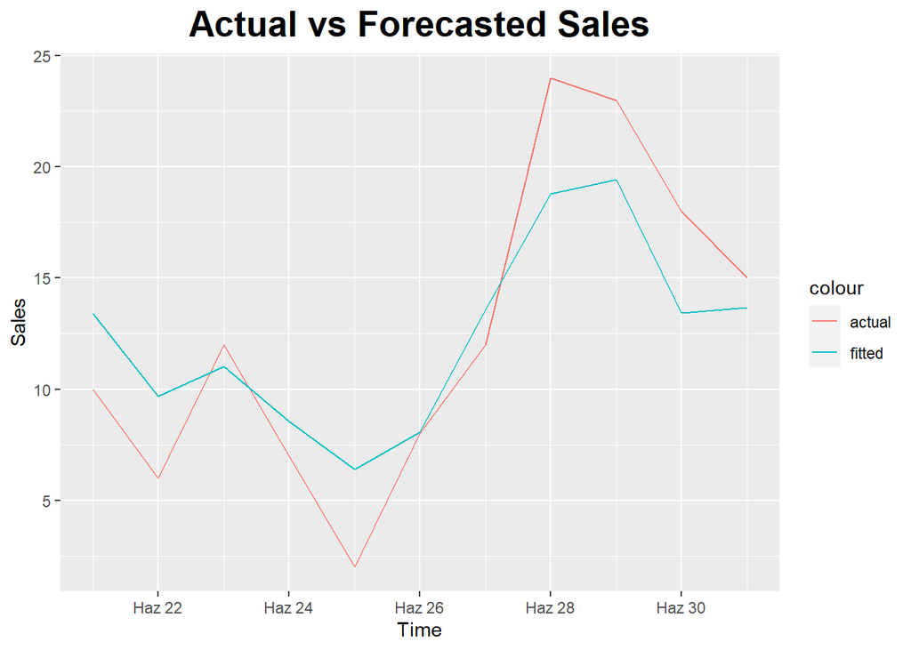

```r
ggplot(vacuum_daily_te ,aes(x=event_date)) +
        geom_line(aes(y=sold_count,color='actual')) +
        geom_line(aes(y=forecastarimax,color='fitted')) + labs(title = "Actual vs Forecasted Sales",
       x = "Time",
       y = "Sales"
       )+
  theme(plot.title = element_text(color = "black", size = 20, face = "bold", hjust = 0.5),
        plot.subtitle = element_text(size = 10, face = "bold", hjust = 0.5),
        plot.caption = element_text(face = "italic", hjust = 0))
```

As can be seen from plot, actual and forecasted values are close to each other and WMAPE is low as desired. Vacuum cleaner sales count explained clearly with favored count, basket count and visit count.

# La Roche Posey Facial Cleanser

## Decomposition

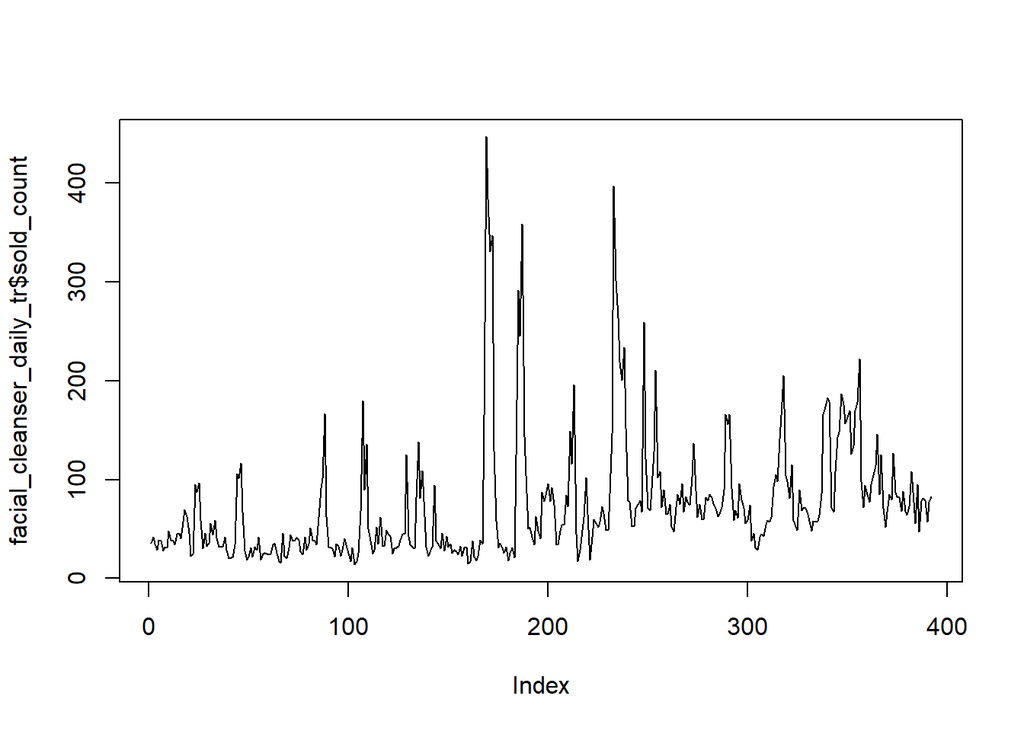

```r
facial_cleanser<-subset(alldata, alldata$product_content_id==85004)
facial_cleanser_daily_tr<-facial_cleanser[facial_cleanser$event_date<"2021-06-21"]
facial_cleanser_daily_te<-facial_cleanser[facial_cleanser$event_date>="2021-06-21"]
plot(facial_cleanser_daily_tr$sold_count, type ='l')
```

Plot above shows daily sales of La Roche Posay face cleanser. Sales of such item increased over time and variance increased at fall and winter term.

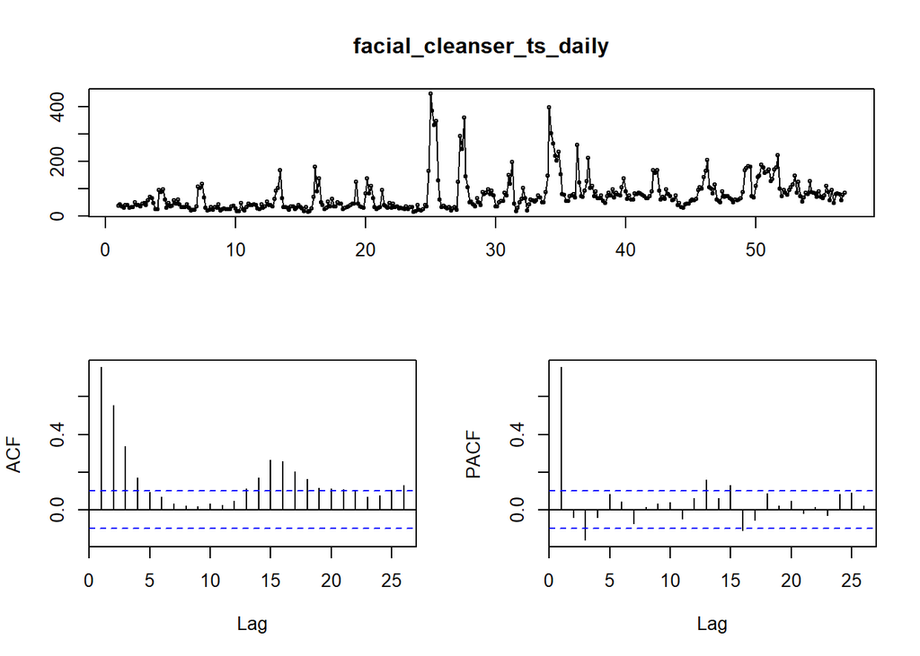

```r
facial_cleanser_ts_daily<-ts(facial_cleanser_daily_tr$sold_count, freq=7)
tsdisplay(facial_cleanser_ts_daily)
```

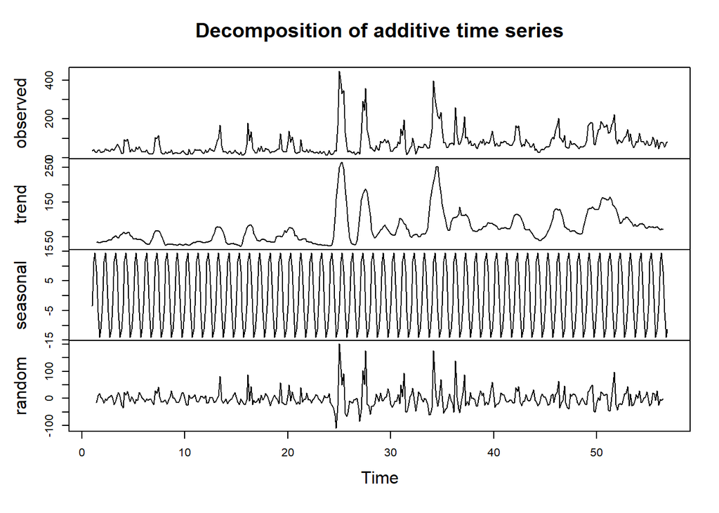

```r
facial_cleanser_daily_additive<-decompose(facial_cleanser_ts_daily, type ="additive")
facial_cleanser_daily_multiplicative<-decompose(facial_cleanser_ts_daily, type ="multiplicative")
plot(facial_cleanser_daily_additive)
```

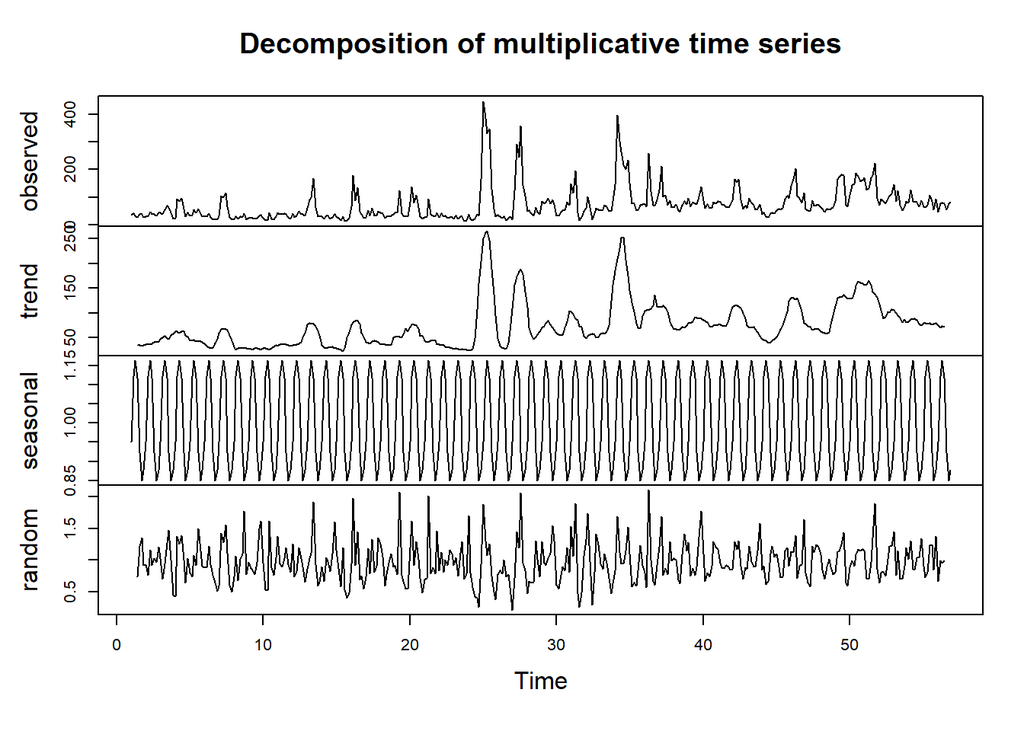

```r
plot(facial_cleanser_daily_multiplicative)
```

Additive decomposition random part has less variance but it is not constant over time. Multiplicative decomposition random part has more variance but it is constant over time. It’s hard to make a definitive statement just by looking at the charts. Therefore, necessary tests will be applied to check stationarity.

```r
test15=ur.kpss(facial_cleanser_daily_additive$random, use.lag="7")
summary(test15)
```

```
##
## #######################
## # KPSS Unit Root Test #
## #######################
##
## Test is of type: mu with 7 lags.
##
## Value of test-statistic is: 0.0092
##
## Critical value for a significance level of:
##                 10pct  5pct 2.5pct  1pct
## critical values 0.347 0.463  0.574 0.739
```

```r
test16=ur.kpss(facial_cleanser_daily_multiplicative$random, use.lag="7")
summary(test16)
```

```
##
## #######################
## # KPSS Unit Root Test #
## #######################
##
## Test is of type: mu with 7 lags.
##
## Value of test-statistic is: 0.1831
##
## Critical value for a significance level of:
##                 10pct  5pct 2.5pct  1pct
## critical values 0.347 0.463  0.574 0.739
```

Additive decomposition method should be chosen since it gives more stationary random part according to test results.

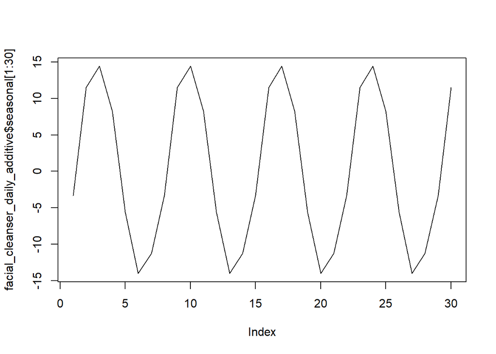

```r
plot(facial_cleanser_daily_additive$seasonal[1:30], type='l')
```

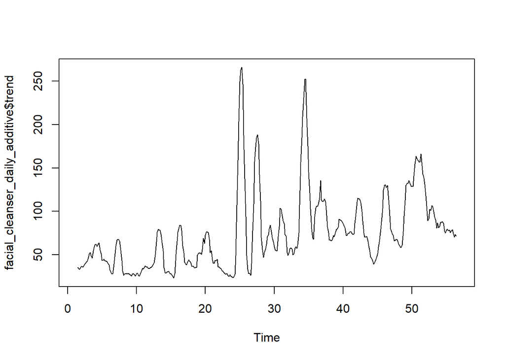

```r
plot(facial_cleanser_daily_additive$trend, type='l')
```

Plots above show closer looks for trend and seasonal components of additive decomposition .

Since there are not enough data points, decomposition cannot made different levels. Altough we cannot decompose, weekly and monthly plots can be seen below.

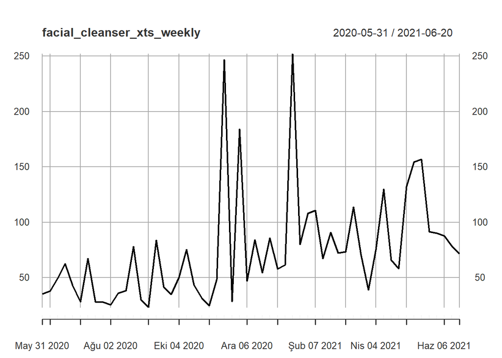

```r
facial_cleanser_xts<-xts(facial_cleanser_daily_tr$sold_count, order.by=as.Date(facial_cleanser_daily_tr$event_date,"%d.%m.%Y"))
weekly<-endpoints(facial_cleanser_xts,on="weeks")
facial_cleanser_xts_weekly<-period.apply(facial_cleanser_xts,INDEX=weekly,FUN=mean)
plot(facial_cleanser_xts_weekly)
```

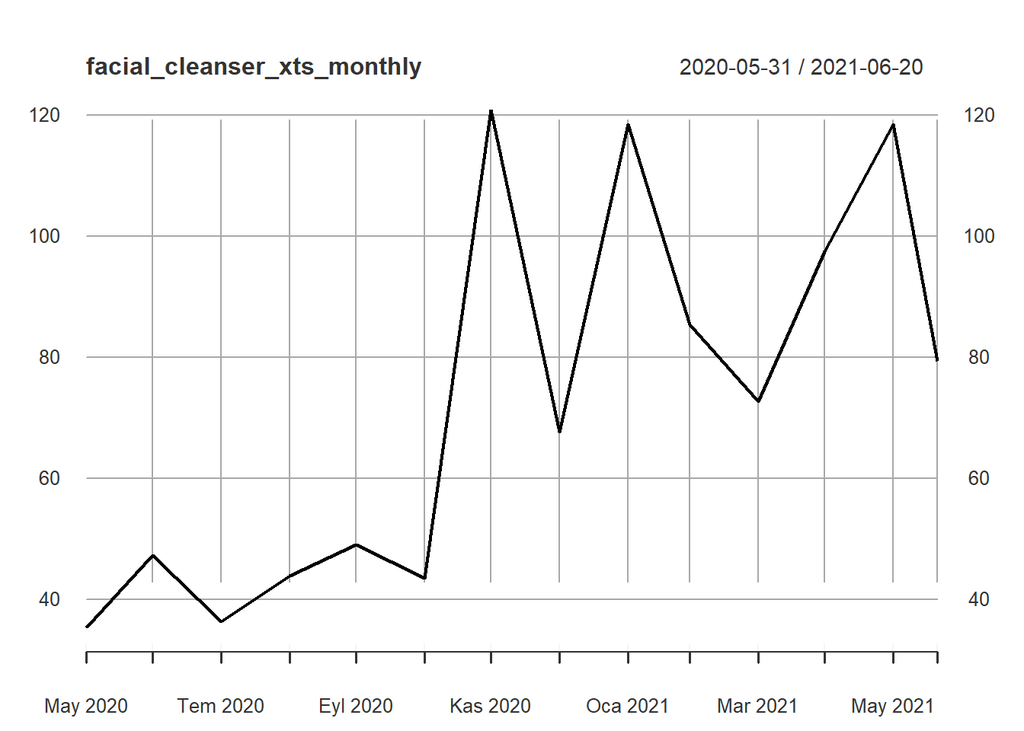

```r
monthly<-endpoints(facial_cleanser_xts,on="months")
facial_cleanser_xts_monthly<-period.apply(facial_cleanser_xts,INDEX=monthly,FUN=mean)
plot(facial_cleanser_xts_monthly)
```

Sales in November are affected from discount days which are determined in our project to yield better forecast result.

## ARIMA Model

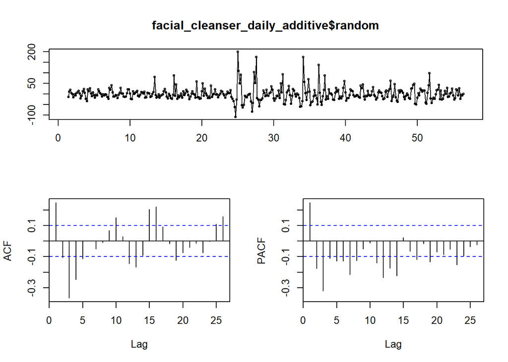

```r
tsdisplay(facial_cleanser_daily_additive$random, na.action = na.omit)
```

According to ACF plot, there is significant negative correlation at lag 3. Hence, moving average parameter should be 3. Also, it can be seen from PACF plot that correlation significantly decreased after lag 1 which means that AR parameter should be 1.

```r
facial_cleanser_model<-arima(facial_cleanser_daily_additive$random, order = c(1,0,3))
AIC(facial_cleanser_model)
```

```
## [1] 3644.424
```

```r
facial_cleanser_model2<-arima(facial_cleanser_daily_additive$random, order = c(1,0,2))
AIC(facial_cleanser_model2)
```

```
## [1] 3753.453
```

```r
facial_cleanser_model3<-arima(facial_cleanser_daily_additive$random, order = c(2,0,2))
AIC(facial_cleanser_model3)
```

```
## [1] 3729.383
```

When adjacent parameters also checked, still model 1 which has (1,0,3) parameters is better in terms of AIC values, therefore it is chosen.

Fitting the model

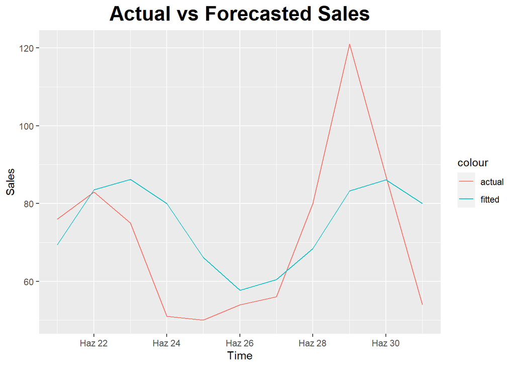

```r
model_forecast_error <- predict(facial_cleanser_model, n.ahead = 11)$pred
last_trend_value <-tail(facial_cleanser_daily_additive$trend[!is.na(facial_cleanser_daily_additive$trend)],1)
seasonality=facial_cleanser_daily_additive$seasonal[295:305]
facial_cleanser_arima_forecast=model_forecast_error+seasonality+last_trend_value

facial_cleanser_daily_te$forecast<-paste(facial_cleanser_arima_forecast)
facial_cleanser_daily_te$forecast<-as.numeric(facial_cleanser_daily_te$forecast)


ggplot(facial_cleanser_daily_te ,aes(x=event_date)) +
        geom_line(aes(y=sold_count,color='actual')) +
        geom_line(aes(y=forecast,color='fitted')) + labs(title = "Actual vs Forecasted Sales",
       x = "Time",
       y = "Sales"
       )+
  theme(plot.title = element_text(color = "black", size = 20, face = "bold", hjust = 0.5),
        plot.subtitle = element_text(size = 10, face = "bold", hjust = 0.5),
        plot.caption = element_text(face = "italic", hjust = 0))
```

```r
error_test(facial_cleanser_daily_te$sold_count,facial_cleanser_daily_te$forecast)
```

```
##    n     mean       sd        bias      mape      mad    wmape        MPE
## 1 11 71.54545 21.59335 -0.04346981 0.2029299 13.45183 0.188018 -0.1021247
```

## Regressor Search

```r
facial_cleanser_lm1<-lm(sold_count~visit_count+is.discount_days, data=facial_cleanser_daily_tr)
summary(facial_cleanser_lm1)
```

```
##
## Call:
## lm(formula = sold_count ~ visit_count + is.discount_days, data = facial_cleanser_daily_tr)
##
## Residuals:
##     Min      1Q  Median      3Q     Max
## -165.19  -24.30  -12.92    8.25  342.08
##
## Coefficients:
##                   Estimate Std. Error t value Pr(>|t|)
## (Intercept)      5.492e+01  3.087e+00  17.790  < 2e-16 ***
## visit_count      8.726e-03  1.153e-03   7.571 2.71e-13 ***
## is.discount_days 1.645e+02  1.303e+01  12.632  < 2e-16 ***
## ---
## Signif. codes:  0 '***' 0.001 '**' 0.01 '*' 0.05 '.' 0.1 ' ' 1
##
## Residual standard error: 49.47 on 389 degrees of freedom
## Multiple R-squared:  0.3605, Adjusted R-squared:  0.3572
## F-statistic: 109.6 on 2 and 389 DF,  p-value: < 2.2e-16
```

```r
facial_cleanser_lm2<-lm(sold_count~category_sold+price, data=facial_cleanser_daily_tr)
summary(facial_cleanser_lm2)
```

```
##
## Call:
## lm(formula = sold_count ~ category_sold + price, data = facial_cleanser_daily_tr)
##
## Residuals:
##     Min      1Q  Median      3Q     Max
## -153.96  -36.21  -15.54   20.80  297.59
##
## Coefficients:
##                 Estimate Std. Error t value Pr(>|t|)
## (Intercept)   358.941849  42.947829   8.358 1.15e-15 ***
## category_sold   0.024796   0.002796   8.869  < 2e-16 ***
## price          -3.855490   0.555368  -6.942 1.63e-11 ***
## ---
## Signif. codes:  0 '***' 0.001 '**' 0.01 '*' 0.05 '.' 0.1 ' ' 1
##
## Residual standard error: 55.27 on 389 degrees of freedom
## Multiple R-squared:  0.2017, Adjusted R-squared:  0.1976
## F-statistic: 49.14 on 2 and 389 DF,  p-value: < 2.2e-16
```

```r
facial_cleanser_lm3<-lm(sold_count~price+favored_count+category_sold, data=facial_cleanser_daily_tr)
summary(facial_cleanser_lm3)
```

```
##
## Call:
## lm(formula = sold_count ~ price + favored_count + category_sold,
##     data = facial_cleanser_daily_tr)
##
## Residuals:
##     Min      1Q  Median      3Q     Max
## -162.66  -24.63   -6.67   15.65  328.02
##
## Coefficients:
##                 Estimate Std. Error t value Pr(>|t|)
## (Intercept)   477.719639  37.749407  12.655  < 2e-16 ***
## price          -5.649418   0.493944 -11.437  < 2e-16 ***
## favored_count   0.060934   0.004961  12.283  < 2e-16 ***
## category_sold   0.018515   0.002430   7.619 1.97e-13 ***
## ---
## Signif. codes:  0 '***' 0.001 '**' 0.01 '*' 0.05 '.' 0.1 ' ' 1
##
## Residual standard error: 46.96 on 388 degrees of freedom
## Multiple R-squared:  0.4252, Adjusted R-squared:  0.4207
## F-statistic: 95.67 on 3 and 388 DF,  p-value: < 2.2e-16
```

```r
facial_cleanser_lm4<-lm(sold_count~favored_count+basket_count+visit_count+is.discount_days+category_sold, data=facial_cleanser_daily_tr)
summary(facial_cleanser_lm4)
```

```
##
## Call:
## lm(formula = sold_count ~ favored_count + basket_count + visit_count +
##     is.discount_days + category_sold, data = facial_cleanser_daily_tr)
##
## Residuals:
##      Min       1Q   Median       3Q      Max
## -141.291   -9.912    0.349    9.431  137.337
##
## Coefficients:
##                    Estimate Std. Error t value Pr(>|t|)
## (Intercept)      -1.023e+01  2.270e+00  -4.507 8.74e-06 ***
## favored_count    -4.531e-03  3.528e-03  -1.284   0.1999
## basket_count      2.934e-01  8.980e-03  32.673  < 2e-16 ***
## visit_count      -1.503e-02  8.611e-04 -17.458  < 2e-16 ***
## is.discount_days  5.102e+01  7.080e+00   7.206 3.06e-12 ***
## category_sold     3.477e-03  1.211e-03   2.872   0.0043 **
## ---
## Signif. codes:  0 '***' 0.001 '**' 0.01 '*' 0.05 '.' 0.1 ' ' 1
##
## Residual standard error: 22.91 on 386 degrees of freedom
## Multiple R-squared:  0.8639, Adjusted R-squared:  0.8621
## F-statistic: 489.9 on 5 and 386 DF,  p-value: < 2.2e-16
```

```r
facial_cleanser_daily_te$forecastlm1<-predict(facial_cleanser_lm1,facial_cleanser_daily_te)
facial_cleanser_daily_te$forecastlm2<-predict(facial_cleanser_lm2,facial_cleanser_daily_te)
facial_cleanser_daily_te$forecastlm3<-predict(facial_cleanser_lm3,facial_cleanser_daily_te)
facial_cleanser_daily_te$forecastlm4<-predict(facial_cleanser_lm4,facial_cleanser_daily_te)

error_test(facial_cleanser_daily_te$sold_count,facial_cleanser_daily_te$forecastlm1)
```

```
##    n     mean       sd        bias      mape     mad     wmape        MPE
## 1 11 71.54545 21.59335 -0.09109016 0.2302715 14.5634 0.2035545 -0.1604838
```

```r
error_test(facial_cleanser_daily_te$sold_count,facial_cleanser_daily_te$forecastlm2)
```

```
##    n     mean       sd       bias      mape      mad     wmape        MPE
## 1 11 71.54545 21.59335 -0.6463231 0.6857502 46.24148 0.6463231 -0.6857502
```

```r
error_test(facial_cleanser_daily_te$sold_count,facial_cleanser_daily_te$forecastlm3)
```

```
##    n     mean       sd       bias     mape      mad     wmape        MPE
## 1 11 71.54545 21.59335 -0.1772046 0.227159 16.42899 0.2296301 -0.1677145
```

```r
error_test(facial_cleanser_daily_te$sold_count,facial_cleanser_daily_te$forecastlm4)
```

```
##    n     mean       sd       bias      mape     mad     wmape        MPE
## 1 11 71.54545 21.59335 0.03935856 0.2557536 16.8197 0.2350911 0.05802043
```

4 different multiple linear regression model is built to understand which regressors are explaining the model better. In terms of adjusted R square, 4th model is explaining sales behavior better than others. When WMAPE is checked, 1st model has minimum value among all models. Nevertheless, 1st and 4th model has close WMAPE values. Therefore, 4th model’s regressors will be chosen which are favored count, basket count, visit count, category sold and discount days.